# Análisis de Ingresos por Género - ESI

# Evolución 2017-2022

Calculamos los promedios entre los años 2017 y 2022 de ingresos principales. Asimismo, verificamos si las diferencias según sexo son estadísticamente significativas

Rechazamos que no existe diferencia significativa en los ingresos medios entre hombres y mujeres (H0) en cada uno de los dataframes, por lo tanto, aceptamos que la diferencia sí es significativa (H1). Los intervalos de confianza no incluyen cero, lo cual refuerza la significancia.

### Ingresos Medios

```r
promedio_ingreso_hombres <- sapply(ocupados_hombres_list, function(df) {
  round(mean(df$ing_t_p, na.rm = TRUE ))
})


promedio_ingreso_mujeres <- sapply(ocupados_mujeres_list, function(df) {
  round(mean(df$ing_t_p, na.rm = TRUE))
})

#En miles

promedios_ingresos <- data.frame(
  Año = años,
  Hombres = promedio_ingreso_hombres,
  Mujeres = promedio_ingreso_mujeres
)


promedio_ingreso_hombres_miles <- round(promedio_ingreso_hombres / 1000)

promedio_ingreso_mujeres_miles <- round(promedio_ingreso_mujeres / 1000)


resultados_ttest <- lapply(1:6, function(i) {
  t.test(ocupados_hombres_list[[i]]$ing_t_p,
         ocupados_mujeres_list[[i]]$ing_t_p,
         alternative = "two.sided",
         var.equal = FALSE,
         na.rm = TRUE)
})

format_p_value <- function(p, digits = 4, eps = .Machine$double.eps) {
  if (p < eps) {
    return(sprintf("< %.0e", eps))
  } else {
    return(format(p, digits = digits, scientific = FALSE))
  }
}

extraer_resultados <- function(test) {
  c(Estadístico_t = round(test$statistic, 2),
    Valor_p = format_p_value(test$p.value, digits = 4, eps = .Machine$double.eps),
    Media_Hombres = round(test$estimate[1], 2),
    Media_Mujeres = round(test$estimate[2], 2),
    IC_Lower = round(test$conf.int[1], 2),
    IC_Upper = round(test$conf.int[2], 2))
}

# Aplicar la función a los resultados de la prueba t
resumen_resultados <- do.call(rbind, lapply(resultados_ttest, extraer_resultados))

# Añadir una columna de categoría para identificar cada par de dataframes
resumen_resultados <- data.frame(Categoria = 1:6, resumen_resultados)

resumen_resultados %>%
  kable(caption = "Resultados de la Prueba t por Categoría") %>%
  kable_styling(bootstrap_options = c("striped", "hover", "condensed"))
```

Resultados de la Prueba t por Categoría

| Categoria | Estadístico_t.t | Valor_p | Media_Hombres.mean.of.x | Media_Mujeres.mean.of.y | IC_Lower | IC_Upper |
| --- | --- | --- | --- | --- | --- | --- |
| 1 | 29.35 | < 2e-16 | 538799.29 | 419180.38 | 111631.82 | 127606.01 |
| 2 | 25.82 | < 2e-16 | 544775.33 | 438416.58 | 98284.84 | 114432.66 |
| 3 | 24.8 | < 2e-16 | 551799.59 | 444029.87 | 99252.27 | 116287.17 |
| 4 | 14.49 | < 2e-16 | 562711.78 | 479160.72 | 72250.16 | 94851.94 |
| 5 | 21.03 | < 2e-16 | 590010.87 | 492227.63 | 88668.67 | 106897.8 |
| 6 | 24.87 | < 2e-16 | 653985.95 | 528882.11 | 115242.6 | 134965.08 |

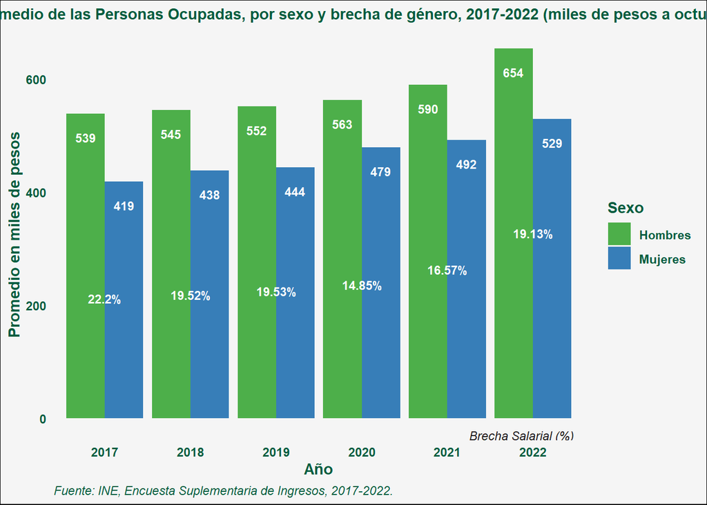

```r
# Mostrar el dataframe con los resultados


#Brecha de ingresos media


brecha_genero_promedios <- round((1- promedio_ingreso_mujeres / promedio_ingreso_hombres) * 100, digits = 2)
# Crear gráfico de barras para promedio de ingresos
promedio_ingreso_miles <- data.frame(
  Año = años,
  Promedio_Hombres = promedio_ingreso_hombres_miles,
  Promedio_Mujeres = promedio_ingreso_mujeres_miles,
  Brecha_Salarial = brecha_genero_promedios
)

palette <- c("#4DAF4A", "#377EB8")

promedio_long <- promedio_ingreso_miles %>%
  pivot_longer(cols = c(Promedio_Hombres, Promedio_Mujeres),
               names_to = "Sexo",
               values_to = "Promedio")

promedio_long$Sexo <- gsub("Promedio_Hombres", "Hombres", promedio_long$Sexo)
promedio_long$Sexo <- gsub("Promedio_Mujeres", "Mujeres", promedio_long$Sexo)


ggplot(promedio_long, aes(x = factor(Año), y = Promedio, fill = Sexo)) +
  geom_bar(stat = "identity", position = "dodge") +
  geom_text(aes(label = Promedio),
            position = position_dodge(width = 0.9),
            vjust = 3.0,
            hjust = 0.5,
            color = "white",
            fontface = "bold",
            size = 3) +
  geom_text(data = distinct(promedio_long, Año, .keep_all = TRUE),
            aes(x = factor(Año),
                label = paste0(Brecha_Salarial, "%")),
            color = "white",
            size = 3,
            fontface = "bold",
            vjust = 20) +
  annotate("text", x = Inf, y = -5, label = "Brecha Salarial (%)",
           hjust = 1.1, vjust = 2, size = 3, color = "#1F1B1C", fontface = "italic") +
  labs(title = "Gráfico 1: Ingreso medio de las Personas Ocupadas, por sexo y brecha de género, 2017-2022 (miles de pesos a octubre 2022)",
       x = "Año",
       y = "Promedio en miles de pesos",
       caption = "Fuente: INE, Encuesta Suplementaria de Ingresos, 2017-2022.") +
  scale_fill_manual(values = palette) +
  scale_y_continuous(labels = scales::comma ) +
  theme_minimal() +
  theme(plot.background = element_rect(fill = "#F5F5F5"),  # Cambiar el fondo a gris claro
        panel.grid.major = element_blank(),  # Eliminar la cuadrícula mayor
        panel.grid.minor = element_blank(),  # Eliminar la cuadrícula menor
        plot.title = element_text(color = "#015D3F", size = 11, hjust = 0.5, face = "bold"),  # Color y tamaño del título
        axis.text = element_text(color = "#015D3F"),  # Color de texto de los ejes
        axis.text.x = element_text(face = "bold"),
        axis.text.y = element_text(face = "bold"),
        axis.title.x = element_text(color = "#015D3F", face = "bold"),  # Color de texto del eje x
        axis.title.y = element_text(color = "#015D3F", face = "bold"),  # Color de texto del eje x
        legend.title = element_text(color = "#015D3F", face = "bold"),  #League of Legends texto y titulo
        legend.text = element_text(color = "#015D3F", face = "bold"),
        plot.caption = element_text(hjust = 0, color = "#015D3F", face = "italic"))
```